# Homework 10: Hypothesis Testing

XDASI Fall 2021

05 November, 2021

## COVID-19 cases in NYC

“NYC_covid_cases_by_age.csv” contains weekly data of cases in NYC over the course of the pandemic.

### 1) Import and tidy the data

Convert the data to long format.

- You should preserve the `week_ending` column, but get rid of the `age_all_ages` column and convert the rest of the columns to two new columns containing the `age_group` and `cases` information.
- Turn the `age_groups` column into a factor.
- Make sure the `week_ending` column is properly formatted as a Date type.

```r
nyc_cases<- read.csv("NYC_covid_cases_by_age.csv")
nyc_cases_long <- nyc_cases %>% gather("age_group", "cases", -week_ending)
nyc_cases_long$age_group<- as.factor(nyc_cases_long$age_group)
nyc_cases_long$week_ending <- as.Date(nyc_cases_long$week_ending, "%m/%d/%Y")
```

### 2) Plot cases over time by age group

Create a plot that shows the trajectory of cases over the course of the pandemic for each of the age groups and for all ages combined.

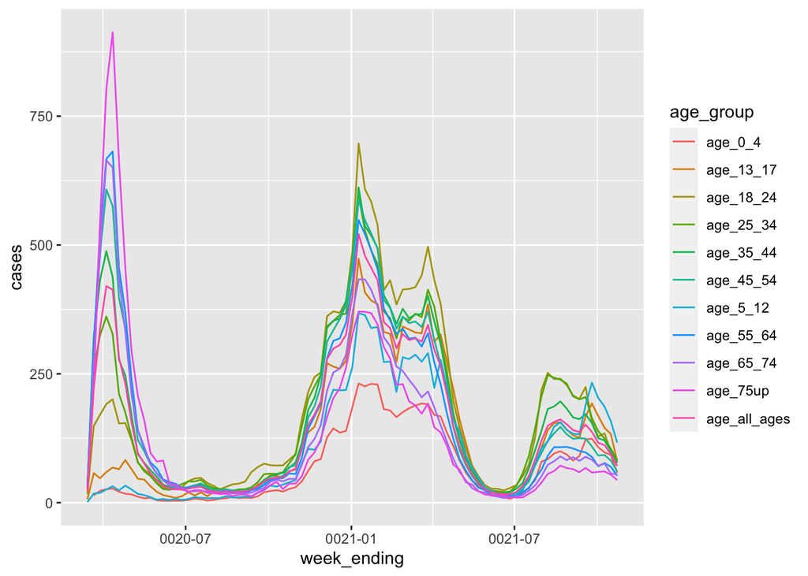

```r
# simple plot
ggplot(nyc_cases_long, aes(x=week_ending, y = cases, color= age_group)) +
  geom_line()
```

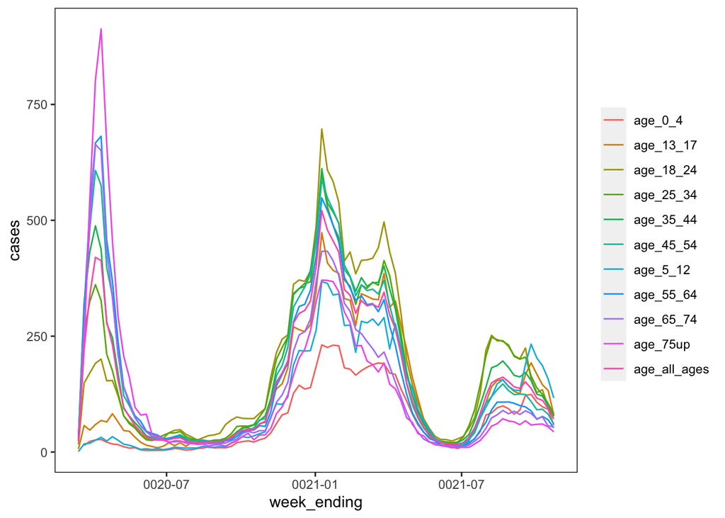

```r
  cases_weekly_plot<- ggplot(nyc_cases_long, aes(x=week_ending, y = cases,
                                               color= age_group)) + # , group= age_group)
  geom_line() +
  theme(panel.background=element_blank(),
        strip.background = element_blank(),
        strip.placement = "outside",
        strip.text=element_blank(),
        panel.border=element_rect(colour="black",fill=NA),
        legend.title = element_blank())
cases_weekly_plot
```

### 3) Significance testing

How would you determine whether there was a statistically significant difference in total cases among people aged 25-34 vs. those aged 75 and over?

1. Explore the data visually using a boxplot, histograms, and qq plots, and perform a test for normality.

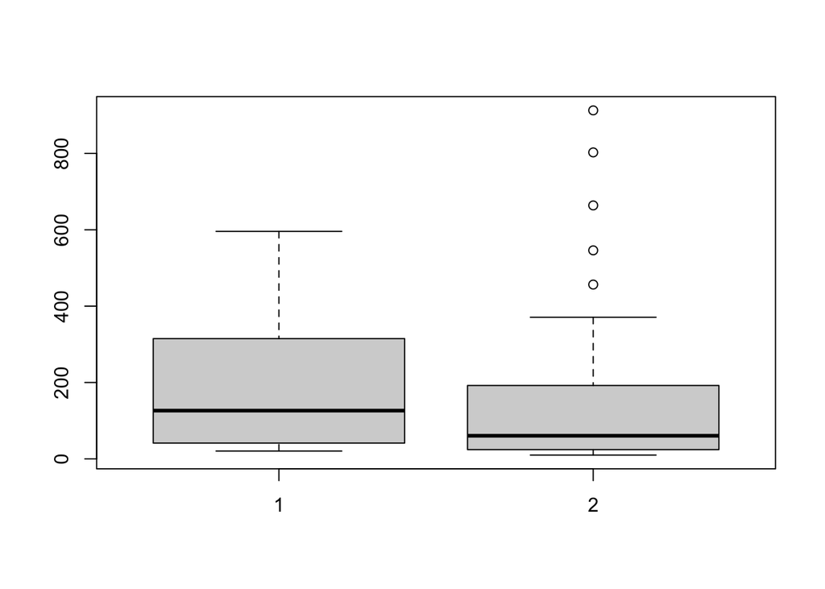

```r
boxplot(nyc_cases$age_25_34, nyc_cases$age_75up)
```

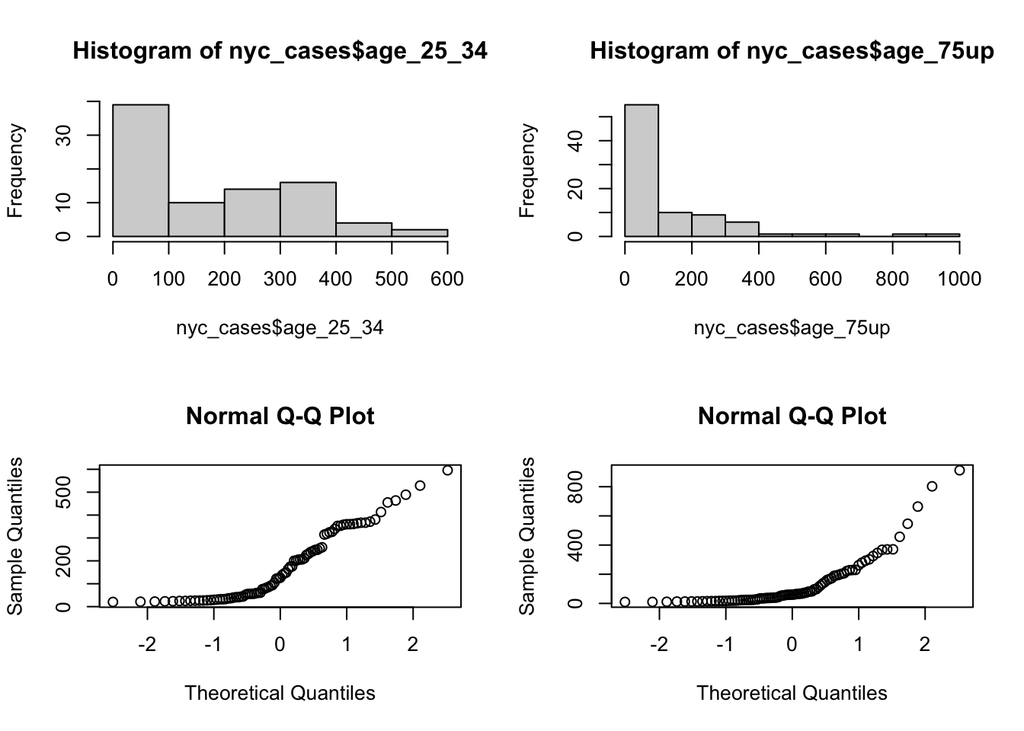

```r
par(mfrow = c(2,2))
hist(nyc_cases$age_25_34)
hist(nyc_cases$age_75up)

qqnorm(nyc_cases$age_25_34)
qqnorm(nyc_cases$age_75up)
```

```r
shapiro.test(nyc_cases$age_25_34)
```

```
##
##  Shapiro-Wilk normality test
##
## data:  nyc_cases$age_25_34
## W = 0.87819, p-value = 8.832e-07
```

```r
shapiro.test(nyc_cases$age_75up)
```

```
##
##  Shapiro-Wilk normality test
##
## data:  nyc_cases$age_75up
## W = 0.69847, p-value = 6.386e-12
```

2. If the data look highly skewed, it might be useful to normalize the data. Do this by converting the total number of cases in each group to a proportion of total cases. Then, rplot and retest for normality.

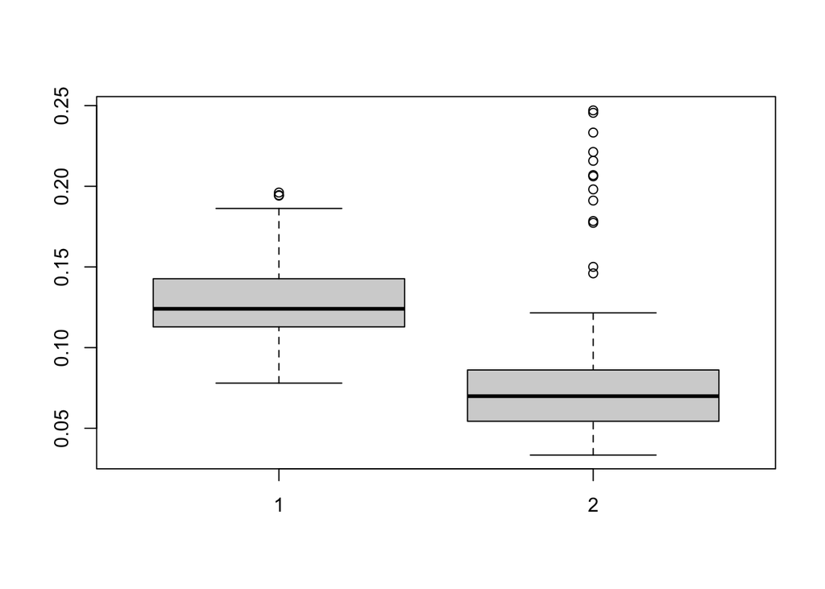

```r
nyc_cases_prop<- nyc_cases_long %>%
  filter(age_group != "age_all_ages")

nyc_cases_prop<- nyc_cases_prop %>%
  drop_na()%>%
  group_by(week_ending) %>%
  mutate(prop = cases/sum(cases))

cases_25_34<-nyc_cases_prop %>%
  filter(age_group == "age_25_34")

cases_75up<-nyc_cases_prop %>%
  filter(age_group == "age_75up")

boxplot(cases_25_34$prop, cases_75up$prop)
```

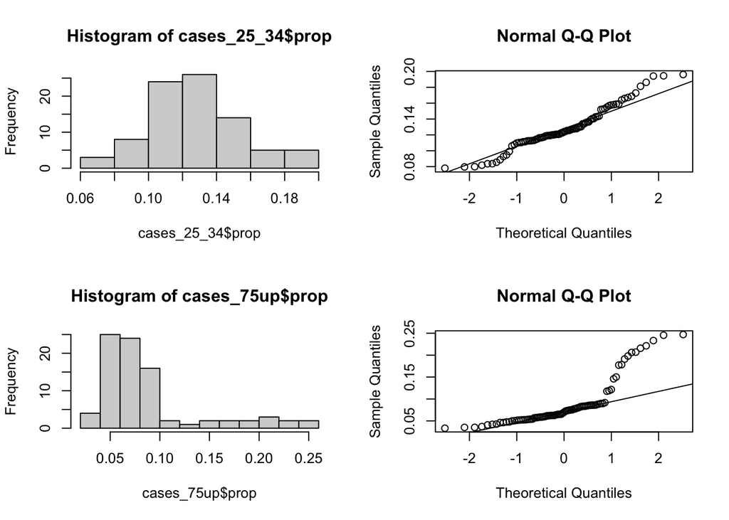

```r
par(mfrow=c(2,2))

hist(cases_25_34$prop)
qqnorm(cases_25_34$prop)
qqline(cases_25_34$prop)

hist(cases_75up$prop)
qqnorm(cases_75up$prop)
qqline(cases_75up$prop)
```

```r
shapiro.test(cases_25_34$prop)
```

```
##
##  Shapiro-Wilk normality test
##
## data:  cases_25_34$prop
## W = 0.95915, p-value = 0.008741
```

```r
shapiro.test(cases_75up$prop)
```

```
##
##  Shapiro-Wilk normality test
##
## data:  cases_75up$prop
## W = 0.747, p-value = 8.549e-11
```

3. Did this help at all? Based on these results, run the appropriate statistical test to compare the proportional distributions of cases in these two groups.

```r
wilcox.test(cases_25_34$prop, cases_75up$prop, paired = F)
```

```
##
##  Wilcoxon rank sum test with continuity correction
##
## data:  cases_25_34$prop and cases_75up$prop
## W = 5968, p-value = 2.144e-13
## alternative hypothesis: true location shift is not equal to 0
```

### 4) Delta strain

Is there a significant difference between the proportion of infections among 25-34 year-olds before and after the rise of the Delta strain? (The Delta strain appeared 6/21/21.)

1. First, check for normality and choose the appropriate test.

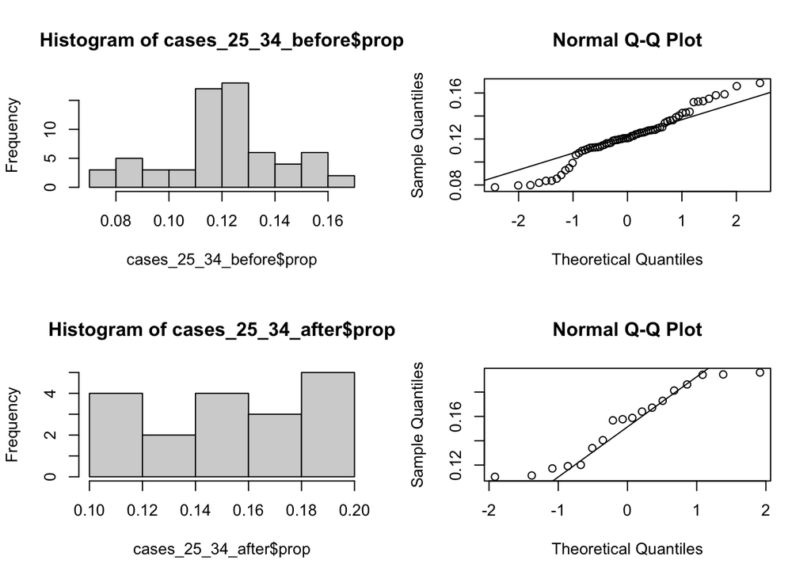

```r
# filter the data
cases_25_34<- cases_25_34%>%
  mutate(Delta= ifelse(week_ending < "0021-06-26", "Before_Delta", "After_Delta"))
cases_25_34$Delta = factor(cases_25_34$Delta,
                           levels=c("Before_Delta","After_Delta"))

cases_25_34_before <- cases_25_34 %>%
  filter(Delta == "Before_Delta")

cases_25_34_after <- cases_25_34 %>%
  filter(Delta == "After_Delta")

# exploratory plots
par(mfrow = c(2,2))
hist(cases_25_34_before$prop)
qqnorm(cases_25_34_before$prop)
qqline(cases_25_34_before$prop)

hist(cases_25_34_after$prop)
qqnorm(cases_25_34_after$prop)
qqline(cases_25_34_after$prop)
```

```r
shapiro.test(cases_25_34_before$prop)
```

```
##
##  Shapiro-Wilk normality test
##
## data:  cases_25_34_before$prop
## W = 0.96796, p-value = 0.08131
```

```r
shapiro.test(cases_25_34_after$prop)
```

```
##
##  Shapiro-Wilk normality test
##
## data:  cases_25_34_after$prop
## W = 0.91588, p-value = 0.1093
```

```r
# statistical test
wilcox.test(cases_25_34_before$prop, cases_25_34_after$prop)
```

```
##
##  Wilcoxon rank sum test with continuity correction
##
## data:  cases_25_34_before$prop and cases_25_34_after$prop
## W = 259, p-value = 0.00022
## alternative hypothesis: true location shift is not equal to 0
```

2. Make a violin plot of the proportion of cases in the 25-34-year old group before and after the appearance of the Delta variant.

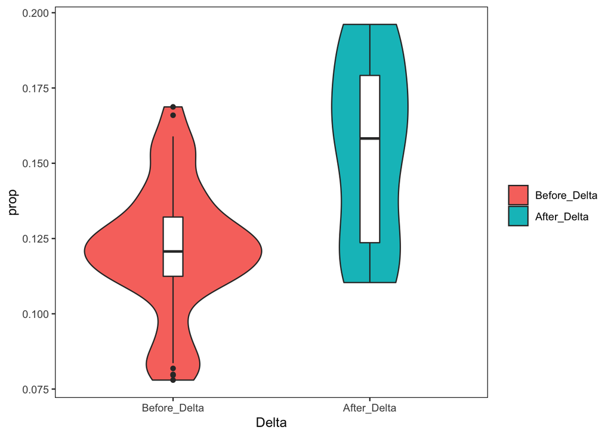

```r
# before and after delta - line plot
# cases_before_after_delta_plot<- ggplot(cases_25_34, aes(x=prop, color= Delta,
#                                                         group= Delta))+
#   geom_density() +
#   theme(panel.background=element_blank(),
#         strip.background = element_blank(),
#         strip.placement = "outside",
#         strip.text=element_blank(),
#         panel.border=element_rect(colour="black",fill=NA),
#         legend.title = element_blank())
# cases_before_after_delta_plot

# violin plot
ggplot(cases_25_34, aes(x= Delta, y=prop, fill= Delta)) +
  geom_violin() +
  geom_boxplot(width=0.1, fill="white") +
  theme(panel.background=element_blank(),
        strip.background = element_blank(),
        strip.placement = "outside",
        strip.text=element_blank(),
        panel.border=element_rect(colour="black",fill=NA),
        legend.title = element_blank())
```

### 5) Breakthrough cases

Consider the following data of the number of NYC documented Covid cases, hospitalizations, and deaths among vaccinated and unvaccinated individuals:

- Cases:
  - Vaccinated: 820
  - Unvaccinated: 4140
- Hospitalizations:
  - Vaccinated: 32
  - Unvaccinated: 349
- Deaths:
  - Vaccinated: 4
  - Unvaccinated: 39

What is an appropriate test you could use to analyze these data? Explain.

```r
# your answer here
Either a Fishers Exact Test or a Chi-square test would work here.

Since the numbers are not so big, it is feasible to perform Fishers
and not too computationally intensive. (People tend to forget that Fishers can
be performed on tables that are larger than two-by-two, but it works fine when
the numbers are not too big).
```

Use this data to create a contingency table, and then perform the appropriate test to determine whether there is a significant difference between the vaccinated and unvaccinated groups.

```r
breakthrough_cases = data.frame(Cases = c(820,4140),
                                Hospitalizations = c(32, 349),
                                Deaths = c(4, 39))
row.names(breakthrough_cases) = c("Vaccinated","Unvaccinated")
breakthrough_cases
```

```
##              Cases Hospitalizations Deaths
## Vaccinated     820               32      4
## Unvaccinated  4140              349     39
```

```r
knitr::kable(breakthrough_cases)
```

|  | Cases | Hospitalizations | Deaths |
| --- | --- | --- | --- |
| Vaccinated | 820 | 32 | 4 |
| Unvaccinated | 4140 | 349 | 39 |

```r
fisher.test(breakthrough_cases)
```

```
##
##  Fisher's Exact Test for Count Data
##
## data:  breakthrough_cases
## p-value = 2.324e-05
## alternative hypothesis: two.sided
```

```r
chisq.test(breakthrough_cases)
```

```
##
##  Pearson's Chi-squared test
##
## data:  breakthrough_cases
## X-squared = 18.915, df = 2, p-value = 7.81e-05
```

The tests work the same either way the table is constructed. By convention, we put the groups we want to compare in the rows with the “focal” group first, and the conditions in the columns.

```r
vaccinated<- c(820,32,4)
unvaccinated<- c(4140,349,39)

breakthrough<- data.frame(vaccinated, unvaccinated)
rownames(breakthrough)<- c("cases", "hospitalizations", "deaths")

fisher.test(breakthrough)
chisq.test(breakthrough)
```

[output not shown]